# CTD + ProDSS Stats

```python
from zipfile import ZipFile
import pandas as pd
import numpy as np

# Unzipping each CSV file from the zip file
def load_csvs_from_zip(zip_name, *, concat=True):
    zipped = ZipFile(zip_name, 'r')
    dfs = {}

    for name in zipped.namelist():
        if name.lower().endswith('.csv'):
            with zipped.open(name) as f:
                df = pd.read_csv(f)
                df['source_file'] = name  # Add source file name
                dfs[name] = df

    if concat:
        return pd.concat(dfs.values(), ignore_index=True)
    else:
        return dfs

# Example:
df_CTD = load_csvs_from_zip('CTD.zip')  # combined into one DataFrame
df_PRODSS = load_csvs_from_zip('ProDSS.zip')  # Now includes 'source_file' column
```

```python
# Takeing out all rows that dont have a vaule in Top_bottom collum
df_CTD = df_CTD[df_CTD['top_bottom'].notna()]
df_CTD
```

|  | date | station | TEMP | CNDC | prSM | PSAL | DEPTH | density | flSP | obs | flag | profile | mld | chla_ugL | top_bottom | mld_surface_subsurface | source_file |
| --- | --- | --- | --- | --- | --- | --- | --- | --- | --- | --- | --- | --- | --- | --- | --- | --- | --- |
| 240 | Feb 05 2025 00:35:51 | Samara S4 deeper site | 26.8971 | 5.250927 | 8.501 | 33.1780 | 8.436 | 1021.4153 | 0.47619 | 0.0 | 0 | up | NaN | 4.7619 | bottom1m | NaN | 2025_02_04_CR_S4_deep_cast 1_modified.csv |
| 241 | Feb 05 2025 00:35:51 | Samara S4 deeper site | 26.9014 | 5.252280 | 8.501 | 33.1845 | 8.436 | 1021.4188 | 0.48840 | 0.0 | 0 | up | NaN | 4.8840 | bottom1m | NaN | 2025_02_04_CR_S4_deep_cast 1_modified.csv |
| 242 | Feb 05 2025 00:35:51 | Samara S4 deeper site | 26.9250 | 5.252577 | 8.501 | 33.1697 | 8.436 | 1021.4002 | 0.52503 | 0.0 | 0 | up | NaN | 5.2503 | bottom1m | NaN | 2025_02_04_CR_S4_deep_cast 1_modified.csv |
| 243 | Feb 05 2025 00:35:51 | Samara S4 deeper site | 27.0009 | 5.258457 | 8.488 | 33.1573 | 8.422 | 1021.3667 | 0.50061 | 0.0 | 0 | up | NaN | 5.0061 | bottom1m | NaN | 2025_02_04_CR_S4_deep_cast 1_modified.csv |
| 244 | Feb 05 2025 00:35:51 | Samara S4 deeper site | 27.0803 | 5.257394 | 8.448 | 33.0932 | 8.383 | 1021.2932 | 0.48840 | 0.0 | 0 | up | NaN | 4.8840 | bottom1m | NaN | 2025_02_04_CR_S4_deep_cast 1_modified.csv |
| ... | ... | ... | ... | ... | ... | ... | ... | ... | ... | ... | ... | ... | ... | ... | ... | ... | ... |
| 3682 | Feb 08 2025 23:19:52 | Papagayo Site 5 | 24.8216 | 5.154136 | 0.321 | 34.0019 | 0.318 | 1022.6424 | 0.50061 | 0.0 | 0 | up | 1.3 | 5.0061 | top1m | above_mld | 2025_02_08_CR_P5_cast 1_modified.csv |
| 3683 | Feb 08 2025 23:19:52 | Papagayo Site 5 | 24.8216 | 5.153835 | 0.268 | 33.9997 | 0.266 | 1022.6405 | 0.46398 | 0.0 | 0 | up | 1.3 | 4.6398 | top1m | above_mld | 2025_02_08_CR_P5_cast 1_modified.csv |
| 3684 | Feb 08 2025 23:19:52 | Papagayo Site 5 | 24.8231 | 5.154740 | 0.188 | 34.0053 | 0.187 | 1022.6439 | 0.45177 | 0.0 | 0 | up | 1.3 | 4.5177 | top1m | above_mld | 2025_02_08_CR_P5_cast 1_modified.csv |
| 3685 | Feb 08 2025 23:19:52 | Papagayo Site 5 | 24.8231 | 5.155494 | 0.109 | 34.0109 | 0.108 | 1022.6478 | 0.46398 | 0.0 | 0 | up | 1.3 | 4.6398 | top1m | above_mld | 2025_02_08_CR_P5_cast 1_modified.csv |
| 3686 | Feb 08 2025 23:19:52 | Papagayo Site 5 | 24.8327 | 5.155343 | 0.016 | 34.0026 | 0.016 | 1022.6383 | 0.00000 | 0.0 | 0 | up | 1.3 | 0.0000 | top1m | above_mld | 2025_02_08_CR_P5_cast 1_modified.csv |

322 rows × 17 columns

```python
#CTF Filtering top and Bottom
# Step 1: Filter out rows with 'nursery' in the Station column (case insensitive)
df_CTD_filtered = df_CTD[~df_CTD['station'].str.contains('nursery', case=False, na=False)]

# Step 2: Filter for rows with only 'top1m' or 'bottom1m' in top_bottom
df_CTD_filtered = df_CTD_filtered[df_CTD_filtered['top_bottom'].isin(['top1m', 'bottom1m'])]


# Step 3: Create four dataframes
# Samara
df_samara_top = df_CTD_filtered[df_CTD_filtered['station'].str.contains('samara', case=False) &
                                (df_CTD_filtered['top_bottom'] == 'top1m')]

df_samara_bottom = df_CTD_filtered[df_CTD_filtered['station'].str.contains('samara', case=False) &
                                   (df_CTD_filtered['top_bottom'] == 'bottom1m')]

# Papagayo
df_papagayo_top = df_CTD_filtered[df_CTD_filtered['station'].str.contains('papagayo', case=False) &
                                  (df_CTD_filtered['top_bottom'] == 'top1m')]

df_papagayo_bottom = df_CTD_filtered[df_CTD_filtered['station'].str.contains('papagayo', case=False) &
                                     (df_CTD_filtered['top_bottom'] == 'bottom1m')]
```

```python
df_CTD_filtered
```

|  | date | station | TEMP | CNDC | prSM | PSAL | DEPTH | density | flSP | obs | flag | profile | mld | chla_ugL | top_bottom | mld_surface_subsurface | source_file |
| --- | --- | --- | --- | --- | --- | --- | --- | --- | --- | --- | --- | --- | --- | --- | --- | --- | --- |
| 240 | Feb 05 2025 00:35:51 | Samara S4 deeper site | 26.8971 | 5.250927 | 8.501 | 33.1780 | 8.436 | 1021.4153 | 0.47619 | 0.0 | 0 | up | NaN | 4.7619 | bottom1m | NaN | 2025_02_04_CR_S4_deep_cast 1_modified.csv |
| 241 | Feb 05 2025 00:35:51 | Samara S4 deeper site | 26.9014 | 5.252280 | 8.501 | 33.1845 | 8.436 | 1021.4188 | 0.48840 | 0.0 | 0 | up | NaN | 4.8840 | bottom1m | NaN | 2025_02_04_CR_S4_deep_cast 1_modified.csv |
| 242 | Feb 05 2025 00:35:51 | Samara S4 deeper site | 26.9250 | 5.252577 | 8.501 | 33.1697 | 8.436 | 1021.4002 | 0.52503 | 0.0 | 0 | up | NaN | 5.2503 | bottom1m | NaN | 2025_02_04_CR_S4_deep_cast 1_modified.csv |
| 243 | Feb 05 2025 00:35:51 | Samara S4 deeper site | 27.0009 | 5.258457 | 8.488 | 33.1573 | 8.422 | 1021.3667 | 0.50061 | 0.0 | 0 | up | NaN | 5.0061 | bottom1m | NaN | 2025_02_04_CR_S4_deep_cast 1_modified.csv |
| 244 | Feb 05 2025 00:35:51 | Samara S4 deeper site | 27.0803 | 5.257394 | 8.448 | 33.0932 | 8.383 | 1021.2932 | 0.48840 | 0.0 | 0 | up | NaN | 4.8840 | bottom1m | NaN | 2025_02_04_CR_S4_deep_cast 1_modified.csv |
| ... | ... | ... | ... | ... | ... | ... | ... | ... | ... | ... | ... | ... | ... | ... | ... | ... | ... |
| 3682 | Feb 08 2025 23:19:52 | Papagayo Site 5 | 24.8216 | 5.154136 | 0.321 | 34.0019 | 0.318 | 1022.6424 | 0.50061 | 0.0 | 0 | up | 1.3 | 5.0061 | top1m | above_mld | 2025_02_08_CR_P5_cast 1_modified.csv |
| 3683 | Feb 08 2025 23:19:52 | Papagayo Site 5 | 24.8216 | 5.153835 | 0.268 | 33.9997 | 0.266 | 1022.6405 | 0.46398 | 0.0 | 0 | up | 1.3 | 4.6398 | top1m | above_mld | 2025_02_08_CR_P5_cast 1_modified.csv |
| 3684 | Feb 08 2025 23:19:52 | Papagayo Site 5 | 24.8231 | 5.154740 | 0.188 | 34.0053 | 0.187 | 1022.6439 | 0.45177 | 0.0 | 0 | up | 1.3 | 4.5177 | top1m | above_mld | 2025_02_08_CR_P5_cast 1_modified.csv |
| 3685 | Feb 08 2025 23:19:52 | Papagayo Site 5 | 24.8231 | 5.155494 | 0.109 | 34.0109 | 0.108 | 1022.6478 | 0.46398 | 0.0 | 0 | up | 1.3 | 4.6398 | top1m | above_mld | 2025_02_08_CR_P5_cast 1_modified.csv |
| 3686 | Feb 08 2025 23:19:52 | Papagayo Site 5 | 24.8327 | 5.155343 | 0.016 | 34.0026 | 0.016 | 1022.6383 | 0.00000 | 0.0 | 0 | up | 1.3 | 0.0000 | top1m | above_mld | 2025_02_08_CR_P5_cast 1_modified.csv |

306 rows × 17 columns

```python
#Clean ProDSS Data

df_PRODSS = df_PRODSS[df_PRODSS['top_bottom'].notna()]
df_PRODSS
```

|  | Date | Time | C | mmHg | DO % | DO mg/L | C-uS/cm | SAL-PSU | Sigma | pH | ... | PE ug/L | PC ug/L | DEP m | VPos m | DEP bar a | DEP bar g | ALT m | profile | top_bottom | source_file |
| --- | --- | --- | --- | --- | --- | --- | --- | --- | --- | --- | --- | --- | --- | --- | --- | --- | --- | --- | --- | --- | --- |
| 23 | 2/3/25 | 16:37:52 | 29.1 | 754.6 | 132.5 | 8.51 | 53391 | 32.29 | 20.0 | 8.04 | ... | NaN | NaN | 2.856 | 2.862 | 0.286 | NaN | 17.0 | down | bottom1m | 020325_ProDSS_S1_modified.csv |
| 24 | 2/3/25 | 16:37:53 | 29.0 | 754.7 | 132.0 | 8.49 | 53335 | 32.29 | 20.0 | 8.04 | ... | NaN | NaN | 3.016 | 2.946 | 0.302 | NaN | 16.8 | down | bottom1m | 020325_ProDSS_S1_modified.csv |
| 25 | 2/3/25 | 16:37:54 | 29.0 | 754.7 | 131.7 | 8.47 | 53307 | 32.29 | 20.1 | 8.04 | ... | NaN | NaN | 3.255 | 3.116 | 0.326 | NaN | 16.9 | down | bottom1m | 020325_ProDSS_S1_modified.csv |
| 26 | 2/3/25 | 16:37:55 | 29.0 | 754.5 | 131.4 | 8.46 | 53286 | 32.29 | 20.1 | 8.04 | ... | NaN | NaN | 3.144 | 3.165 | 0.315 | NaN | 16.8 | down | bottom1m | 020325_ProDSS_S1_modified.csv |
| 27 | 2/3/25 | 16:37:56 | 29.0 | 754.5 | 131.1 | 8.44 | 53275 | 32.29 | 20.1 | 8.04 | ... | NaN | NaN | 3.216 | 3.274 | 0.322 | NaN | 16.8 | down | bottom1m | 020325_ProDSS_S1_modified.csv |
| ... | ... | ... | ... | ... | ... | ... | ... | ... | ... | ... | ... | ... | ... | ... | ... | ... | ... | ... | ... | ... | ... |
| 2006 | 2/3/25 | 15:01:51 | 28.8 | 755.6 | 112.4 | 7.26 | 53177 | 32.35 | 20.2 | 8.03 | ... | NaN | NaN | 0.313 | 0.317 | 0.031 | NaN | 10.6 | up | top1m | 020325_ProDSS_Samara_coral nursery_modified.csv |
| 2007 | 2/3/25 | 15:01:53 | 28.8 | 755.6 | 112.5 | 7.26 | 53195 | 32.36 | 20.2 | 8.03 | ... | NaN | NaN | 0.314 | 0.312 | 0.031 | NaN | 10.7 | up | top1m | 020325_ProDSS_Samara_coral nursery_modified.csv |
| 2008 | 2/3/25 | 15:01:54 | 28.8 | 755.6 | 112.6 | 7.27 | 53202 | 32.36 | 20.2 | 8.03 | ... | NaN | NaN | 0.313 | 0.306 | 0.031 | NaN | 10.8 | up | top1m | 020325_ProDSS_Samara_coral nursery_modified.csv |
| 2009 | 2/3/25 | 15:01:55 | 28.8 | 755.6 | 112.6 | 7.27 | 53203 | 32.36 | 20.2 | 8.03 | ... | NaN | NaN | 0.314 | 0.319 | 0.031 | NaN | 11.0 | up | top1m | 020325_ProDSS_Samara_coral nursery_modified.csv |
| 2010 | 2/3/25 | 15:01:56 | 28.8 | 755.6 | 112.6 | 7.27 | 53199 | 32.35 | 20.1 | 8.03 | ... | NaN | NaN | 0.315 | 0.325 | 0.032 | NaN | 11.3 | up | top1m | 020325_ProDSS_Samara_coral nursery_modified.csv |

1034 rows × 27 columns

```python
#Getting ride of the coral nursry for Pro DSS Data
df_PRODSS = df_PRODSS[df_PRODSS['top_bottom'].notna()].copy()

df_PRODSS['Date'] = pd.to_datetime(df_PRODSS['Date']).dt.normalize()

papagayo_dates = pd.to_datetime(['2025-02-06','2025-02-07','2025-02-08'])
samara_dates = pd.to_datetime(['2025-02-02','2025-02-03','2025-02-04'])

df_PRODSS.loc[df_PRODSS['Date'].isin(papagayo_dates), 'station'] = 'Papagayo'
df_PRODSS.loc[df_PRODSS['Date'].isin(samara_dates), 'station'] = 'Samara'

# ⭐ CLEAN FILTER GOES HERE (IMPORTANT STEP)
df_PRODSS_clean = df_PRODSS[
    df_PRODSS['station'].notna() &
    df_PRODSS['top_bottom'].isin(['top1m','bottom1m']) &
    ~df_PRODSS['source_file'].str.contains('nursery|restoration', case=False, na=False)
].copy()
```

```python
#Check to make sure you getting ride of the coral nursry for Pro DSS Data
df_PRODSS_clean['source_file'].value_counts()
```

```
source_file
020225_ProDSS_S2_modified.csv        156
020825_ProDSS_P5_modified.csv        123
020425_ProDSS_S4deep_modified.csv    119
020725_ProDSS_P4_modified.csv         97
020225_ProDSS_S1_modified.csv         66
020725_ProDSS_P3_modified.csv         60
020425_ProDSS_S1_modified.csv         59
020625_ProDSS_P2_modified.csv         55
020325_ProDSS_S3d_modified.csv        54
020625_ProDSS_P1_modified.csv         45
020825_ProDSS_P6_modified.csv         45
020325_ProDSS_S1_modified.csv         36
Name: count, dtype: int64
```

```python
#Filter ProDSS for bottom 1 m + Check

df_PRODSS_samara_bottom = df_PRODSS_clean.query(
    "station == 'Samara' and top_bottom == 'bottom1m'"
)

df_PRODSS_papagayo_bottom = df_PRODSS_clean.query(
    "station == 'Papagayo' and top_bottom == 'bottom1m'"
)

df_PRODSS_samara_bottom['source_file'].value_counts()
```

```
source_file
020425_ProDSS_S4deep_modified.csv    99
020225_ProDSS_S1_modified.csv        51
020225_ProDSS_S2_modified.csv        49
020425_ProDSS_S1_modified.csv        45
020325_ProDSS_S1_modified.csv        36
020325_ProDSS_S3d_modified.csv       34
Name: count, dtype: int64
```

```python
#make CSV Files from the Data for each locations

df_PRODSS_papagayo_bottom.to_csv('PRODSS_papagayo.csv', index=False)
df_PRODSS_samara_bottom.to_csv('PRODSS_samara.csv', index=False)
```

```python
print (df_papagayo_bottom)
print (df_samara_bottom)
print (df_PRODSS_papagayo_bottom)
print (df_PRODSS_samara_bottom)
```

```
                      date          station     TEMP      CNDC   prSM  \
770   Feb 08 2025 23:20:15  Papagayo Site 6  24.7810  5.151178  9.260
771   Feb 08 2025 23:20:15  Papagayo Site 6  24.7802  5.151324  9.260
772   Feb 08 2025 23:20:15  Papagayo Site 6  24.7824  5.151168  9.246
773   Feb 08 2025 23:20:15  Papagayo Site 6  24.7817  5.151464  9.193
774   Feb 08 2025 23:20:15  Papagayo Site 6  24.7831  5.151308  9.167
...                    ...              ...      ...       ...    ...
3583  Feb 08 2025 23:19:52  Papagayo Site 5  24.5317  5.130059  9.060
3584  Feb 08 2025 23:19:52  Papagayo Site 5  24.5317  5.130364  8.993
3585  Feb 08 2025 23:19:52  Papagayo Site 5  24.5340  5.130518  8.807
3586  Feb 08 2025 23:19:52  Papagayo Site 5  24.5340  5.130521  8.674
3587  Feb 08 2025 23:19:52  Papagayo Site 5  24.5347  5.130524  8.634

         PSAL  DEPTH    density     flSP  obs  flag profile  mld  chla_ugL  \
770   34.0079  9.189  1022.6978  0.61050  0.0     0      up  NaN    6.1050
```

[output cut: 158 more lines]

```python
#Combinging the Prodss data frames from Samara and papagayo (no coral nursrty) + Combining the CTD Data Frames from Samara and papagayo

df_CTD_combined = pd.concat(
    [df_papagayo_bottom, df_samara_bottom],
    ignore_index=True
)

df_PRODSS_combined = pd.concat(
    [df_PRODSS_papagayo_bottom, df_PRODSS_samara_bottom],
    ignore_index=True
)


df_CTD_combined['station_simple'] = df_CTD_combined['station'].str.extract(r'^(Samara|Papagayo)')
df_PRODSS_combined['station_simple'] = df_PRODSS_combined['station'].str.extract(r'^(Samara|Papagayo)')
```

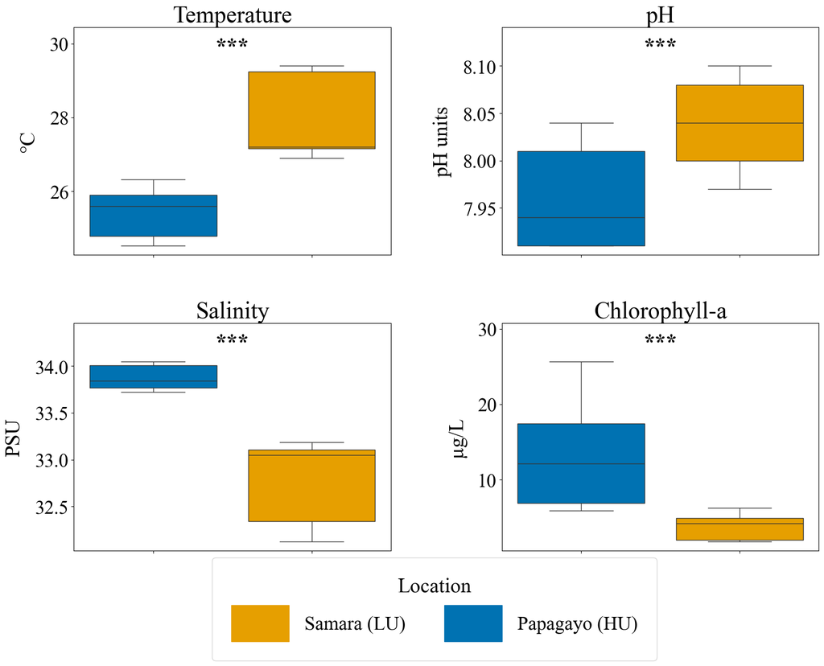

```python
import matplotlib.pyplot as plt
import seaborn as sns
import matplotlib.patches as mpatches

# --------------------------
# GLOBAL FONT SETTINGS
# --------------------------
plt.rcParams.update({
    "font.family": "Times New Roman",
    "font.size": 26,
    "axes.titlesize": 32,
    "axes.labelsize": 28,
    "xtick.labelsize": 26,
    "ytick.labelsize": 26,
    "legend.fontsize": 26
})

# --------------------------
# PLOTTING SETTINGS
# --------------------------
title_fontsize = 32
ylabel_fontsize = 28
ylabel_ticksize = 26

station_order = ['Papagayo', 'Samara']

station_colors = {
    'Samara': '#E69F00',   # orange
    'Papagayo': '#0072B2'  # blue
}

plot_vars = ['TEMP', 'pH', 'PSAL', 'chla_ugL']

# --------------------------
# FIGURE SETUP (2x2 GRID)
# --------------------------
fig, axes = plt.subplots(2, 2, figsize=(18, 14))
axes = axes.flatten()

# Store y-limits for post-processing
ylim_store = {}

# --------------------------
# MAIN PLOTTING LOOP
# --------------------------
for ax, var in zip(axes, plot_vars):

    # Select correct dataframe
    if var in ['TEMP', 'PSAL', 'chla_ugL']:
        df_plot = df_CTD_combined
    else:
        df_plot = df_PRODSS_combined

    sns.boxplot(
        data=df_plot,
        x='station_simple',
        y=var,
        hue='station_simple',
        order=station_order,
        hue_order=station_order,
        palette=station_colors,
        ax=ax,
        legend=False,
        saturation=1
    )

    ax.set_title(custom_titles.get(var, var), fontsize=title_fontsize)
    ax.set_xlabel('')
    ax.set_xticklabels([])

    ax.set_ylabel(
        custom_ylabels.get(var, var),
        fontsize=ylabel_fontsize,
        labelpad=15
    )

    ax.tick_params(axis='y', labelsize=ylabel_ticksize)

    # Store original y-limits BEFORE layout adjustments
    ylim_store[var] = ax.get_ylim()

# --------------------------
# ADD WHITE SPACE + STARS
# --------------------------
for ax, var in zip(axes, plot_vars):
    ymin, ymax = ylim_store[var]
    data_range = ymax - ymin
    headroom = data_range * 0.15

    ax.set_ylim(ymin, ymax + headroom)

    ax.text(
        0.5,
        ymax + headroom * 0.3,
        '***',
        ha='center',
        va='center',
        fontsize=30,
        fontweight='bold'
    )

# --------------------------
# LEGEND
# --------------------------
sam_patch = mpatches.Patch(color='#E69F00', label='Samara (LU)')
pap_patch = mpatches.Patch(color='#0072B2', label='Papagayo (HU)')

fig.legend(
    handles=[sam_patch, pap_patch],
    loc='lower center',
    ncol=2,
    fontsize=26,
    title='Location',
    title_fontsize=28,
    frameon=True,
    borderpad=1.0,
    handlelength=3.0,
    handleheight=2.5,
    bbox_to_anchor=(0.5, 0.02)
)

# Leave space for legend
plt.subplots_adjust(bottom=0.18)
plt.subplots_adjust(wspace=0.35, hspace=0.30)

# --------------------------
# SAVE & SHOW
# --------------------------
plt.savefig("ENVFIG_poster.png", dpi=600, bbox_inches='tight')
plt.show()
```

```python
# Double check to make sure we are ony using data points from bottom 1 m
assert all(df_papagayo_bottom['top_bottom'] == 'bottom1m')
assert all(df_samara_bottom['top_bottom'] == 'bottom1m')
```

```python
import pandas as pd
import scipy.stats as stats

# --------------------------
# VARIABLES
# --------------------------
ctd_vars = ["TEMP", "PSAL", "chla_ugL"]
prodss_vars = ["pH"]

results = []

# --------------------------
# USE COMBINED DATASETS
# --------------------------
datasets = {
    "CTD": df_CTD_combined.copy(),
    "ProDSS": df_PRODSS_combined.copy()
}

# ensure station_simple exists (safe fix)
for name in datasets:
    datasets[name]["station_simple"] = datasets[name]["station_simple"].astype(str)

# --------------------------
# FUNCTION FOR TESTING
# --------------------------
def run_tests(df, vars_list, dataset_name):

    for var in vars_list:

        group1 = df[df["station_simple"] == "Papagayo"][var].dropna()
        group2 = df[df["station_simple"] == "Samara"][var].dropna()

        # skip if too small
        if len(group1) < 3 or len(group2) < 3:
            continue

        # --------------------------
        # NORMALITY
        # --------------------------
        shapiro1 = stats.shapiro(group1)
        shapiro2 = stats.shapiro(group2)

        normal = (shapiro1.pvalue > 0.05) and (shapiro2.pvalue > 0.05)

        # --------------------------
        # TEST SELECTION
        # --------------------------
        if normal:
            test_name = "t-test"
            stat, pval = stats.ttest_ind(group1, group2, equal_var=False)
        else:
            test_name = "Mann-Whitney U"
            stat, pval = stats.mannwhitneyu(group1, group2, alternative="two-sided")

        results.append({
            "Dataset": dataset_name,
            "Variable": var,
            "Test": test_name,
            "Statistic": stat,
            "p-value": pval,
            "n_Papagayo": len(group1),
            "n_Samara": len(group2),
            "Shapiro_Papagayo": shapiro1.pvalue,
            "Shapiro_Samara": shapiro2.pvalue
        })

# --------------------------
# RUN BOTH DATASETS
# --------------------------
run_tests(datasets["CTD"], ctd_vars, "CTD")
run_tests(datasets["ProDSS"], prodss_vars, "ProDSS")

# --------------------------
# OUTPUT
# --------------------------
results_df = pd.DataFrame(results)
print(results_df)
```

```
  Dataset  Variable            Test  Statistic       p-value  n_Papagayo  \
0     CTD      TEMP  Mann-Whitney U        0.0  1.566001e-18         100
1     CTD      PSAL  Mann-Whitney U     3500.0  1.569288e-18         100
2     CTD  chla_ugL  Mann-Whitney U     3490.5  2.371352e-18         100
3  ProDSS        pH  Mann-Whitney U    14671.0  4.080665e-56         328

   n_Samara  Shapiro_Papagayo  Shapiro_Samara
0        35      2.268817e-07    7.003682e-07
1        35      1.870471e-08    2.970272e-06
2        35      5.327460e-06    4.143227e-05
3       314      2.340539e-20    5.696584e-11
```

```python
# Checking for varibility within locations: Papagayo

import pandas as pd
import scipy.stats as stats
import scikit_posthocs as sp

# --------------------------
# VARIABLES
# --------------------------
ctd_vars = ["TEMP", "PSAL", "chla_ugL"]
prodss_vars = ["pH"]

results = []
dunn_results = {}

# ======================================================
# ----------- CTD PAPAGAYO ------------------------------
# ======================================================
df_papagayo_ctd = df_papagayo_bottom.copy()

sites_ctd = df_papagayo_ctd['source_file'].dropna().unique()
print("CTD Papagayo casts:", sites_ctd)

for var in ctd_vars:

    df_var = df_papagayo_ctd[['source_file', var]].dropna()

    groups = [
        df_var[df_var['source_file'] == s][var]
        for s in sites_ctd
    ]
    groups = [g for g in groups if len(g) > 2]

    # --------------------------
    # NORMALITY
    # --------------------------
    shapiro_pvals = [stats.shapiro(g).pvalue for g in groups if len(g) >= 3]
    normal = all(p > 0.05 for p in shapiro_pvals)

    # --------------------------
    # MAIN TEST
    # --------------------------
    if normal:
        test_name = "One-way ANOVA"
        stat, pval = stats.f_oneway(*groups)
    else:
        test_name = "Kruskal-Wallis"
        stat, pval = stats.kruskal(*groups)

    # --------------------------
    # DUNN'S TEST
    # --------------------------
    if test_name == "Kruskal-Wallis" and pval < 0.05:
        dunn = sp.posthoc_dunn(
            df_var,
            val_col=var,
            group_col='source_file',
            p_adjust='bonferroni'
        )
        dunn_results[f"CTD_Papagayo_{var}"] = dunn

    results.append({
        "Dataset": "CTD",
        "Location": "Papagayo",
        "Variable": var,
        "Test": test_name,
        "Statistic": stat,
        "p-value": pval,
        "n_groups": len(groups)
    })


# ======================================================
# ----------- PRODSS PAPAGAYO ---------------------------
# ======================================================
df_papagayo_prodss = df_PRODSS_papagayo_bottom.copy()

sites_prodss = df_papagayo_prodss['source_file'].dropna().unique()
print("\nProDSS Papagayo casts:", sites_prodss)

for var in prodss_vars:

    df_var = df_papagayo_prodss[['source_file', var]].dropna()

    groups = [
        df_var[df_var['source_file'] == s][var]
        for s in sites_prodss
    ]
    groups = [g for g in groups if len(g) > 2]

    # Normality
    shapiro_pvals = [stats.shapiro(g).pvalue for g in groups if len(g) >= 3]
    normal = all(p > 0.05 for p in shapiro_pvals)

    # Main test
    if normal:
        test_name = "One-way ANOVA"
        stat, pval = stats.f_oneway(*groups)
    else:
        test_name = "Kruskal-Wallis"
        stat, pval = stats.kruskal(*groups)

    # Dunn's test
    if test_name == "Kruskal-Wallis" and pval < 0.05:
        dunn = sp.posthoc_dunn(
            df_var,
            val_col=var,
            group_col='source_file',
            p_adjust='bonferroni'
        )
        dunn_results[f"ProDSS_Papagayo_{var}"] = dunn

    results.append({
        "Dataset": "ProDSS",
        "Location": "Papagayo",
        "Variable": var,
        "Test": test_name,
        "Statistic": stat,
        "p-value": pval,
        "n_groups": len(groups)
    })


# ======================================================
# OUTPUT
# ======================================================
results_df = pd.DataFrame(results)

print("\nMAIN RESULTS (Papagayo):")
print(results_df)

print("\nDUNN POST-HOC RESULTS (Papagayo):")
for key, val in dunn_results.items():
    print(f"\n{key}")
    print(val)
```

```
CTD Papagayo casts: ['2025_02_08_CR_P6_cast 1_modified.csv'
 '2025_02_06_CR_P2_cast 1_modified.csv'
 '2025_02_06_CR_P1_cast 1_modified.csv'
 '2025_02_07_CR_P4_cast 1_modified.csv'
 '2025_02_07_CR_P3_cast 1_modified.csv'
 '2025_02_08_CR_P5_cast 1_modified.csv']

ProDSS Papagayo casts: ['020625_ProDSS_P2_modified.csv' '020625_ProDSS_P1_modified.csv'
 '020825_ProDSS_P6_modified.csv' '020725_ProDSS_P3_modified.csv'
 '020725_ProDSS_P4_modified.csv' '020825_ProDSS_P5_modified.csv']

MAIN RESULTS (Papagayo):
  Dataset  Location  Variable            Test   Statistic       p-value  \
0     CTD  Papagayo      TEMP  Kruskal-Wallis   95.540756  4.594672e-19
1     CTD  Papagayo      PSAL  Kruskal-Wallis   95.528713  4.621565e-19
2     CTD  Papagayo  chla_ugL  Kruskal-Wallis   90.297122  5.819773e-18
3  ProDSS  Papagayo        pH  Kruskal-Wallis  321.872851  1.979635e-67

   n_groups
0         6
1         6
2         6
3         6

DUNN POST-HOC RESULTS (Papagayo):

CTD_Papagayo_TEMP
                                      2025_02_06_CR_P1_cast 1_modified.csv  \
2025_02_06_CR_P1_cast 1_modified.csv                          1.000000e+00
2025_02_06_CR_P2_cast 1_modified.csv                          1.000000e+00
2025_02_07_CR_P3_cast 1_modified.csv                          3.222193e-02
2025_02_07_CR_P4_cast 1_modified.csv                          1.905331e-01
2025_02_08_CR_P5_cast 1_modified.csv                          7.055283e-10
2025_02_08_CR_P6_cast 1_modified.csv                          5.111880e-05

                                      2025_02_06_CR_P2_cast 1_modified.csv  \
2025_02_06_CR_P1_cast 1_modified.csv                              1.000000
2025_02_06_CR_P2_cast 1_modified.csv                              1.000000
2025_02_07_CR_P3_cast 1_modified.csv                              1.000000
2025_02_07_CR_P4_cast 1_modified.csv                              0.024553
```

[output cut: 166 more lines]

```
                               020825_ProDSS_P5_modified.csv  \
020625_ProDSS_P1_modified.csv                   3.189147e-38
020625_ProDSS_P2_modified.csv                   4.458074e-35
020725_ProDSS_P3_modified.csv                   2.480765e-06
020725_ProDSS_P4_modified.csv                   6.264738e-26
020825_ProDSS_P5_modified.csv                   1.000000e+00
020825_ProDSS_P6_modified.csv                   1.000000e+00

                               020825_ProDSS_P6_modified.csv
020625_ProDSS_P1_modified.csv                   5.507635e-25
020625_ProDSS_P2_modified.csv                   7.908829e-21
020725_ProDSS_P3_modified.csv                   7.498935e-04
020725_ProDSS_P4_modified.csv                   3.781882e-13
020825_ProDSS_P5_modified.csv                   1.000000e+00
020825_ProDSS_P6_modified.csv                   1.000000e+00
```

```python
# Checking for varibility within locations: Samara


import pandas as pd
import scipy.stats as stats
import scikit_posthocs as sp

# --------------------------
# VARIABLES
# --------------------------
ctd_vars = ["TEMP", "PSAL", "chla_ugL"]
prodss_vars = ["pH"]

results = []
dunn_results = {}

# ======================================================
# ----------- CTD SAMARA ONLY ---------------------------
# ======================================================
df_samara_ctd = df_samara_bottom.copy()

sites_ctd = df_samara_ctd['source_file'].dropna().unique()
print("CTD Samara casts:", sites_ctd)

for var in ctd_vars:

    df_var = df_samara_ctd[['source_file', var]].dropna()

    groups = [
        df_var[df_var['source_file'] == s][var]
        for s in sites_ctd
    ]
    groups = [g for g in groups if len(g) > 2]

    # Normality
    shapiro_pvals = [stats.shapiro(g).pvalue for g in groups if len(g) >= 3]
    normal = all(p > 0.05 for p in shapiro_pvals)

    # Main test
    if normal:
        test_name = "One-way ANOVA"
        stat, pval = stats.f_oneway(*groups)
    else:
        test_name = "Kruskal-Wallis"
        stat, pval = stats.kruskal(*groups)

    # Dunn's test (ONLY if needed)
    if test_name == "Kruskal-Wallis" and pval < 0.05:
        dunn = sp.posthoc_dunn(
            df_var,
            val_col=var,
            group_col='source_file',
            p_adjust='bonferroni'
        )
        dunn_results[f"CTD_Samara_{var}"] = dunn

    results.append({
        "Dataset": "CTD",
        "Location": "Samara",
        "Variable": var,
        "Test": test_name,
        "Statistic": stat,
        "p-value": pval,
        "n_groups": len(groups)
    })


# ======================================================
# ----------- PRODSS SAMARA ONLY ------------------------
# ======================================================
df_samara_prodss = df_PRODSS_samara_bottom.copy()

sites_prodss = df_samara_prodss['source_file'].dropna().unique()
print("\nProDSS Samara casts:", sites_prodss)

for var in prodss_vars:

    df_var = df_samara_prodss[['source_file', var]].dropna()

    groups = [
        df_var[df_var['source_file'] == s][var]
        for s in sites_prodss
    ]
    groups = [g for g in groups if len(g) > 2]

    shapiro_pvals = [stats.shapiro(g).pvalue for g in groups if len(g) >= 3]
    normal = all(p > 0.05 for p in shapiro_pvals)

    if normal:
        test_name = "One-way ANOVA"
        stat, pval = stats.f_oneway(*groups)
    else:
        test_name = "Kruskal-Wallis"
        stat, pval = stats.kruskal(*groups)

    # Dunn's test
    if test_name == "Kruskal-Wallis" and pval < 0.05:
        dunn = sp.posthoc_dunn(
            df_var,
            val_col=var,
            group_col='source_file',
            p_adjust='bonferroni'
        )
        dunn_results[f"ProDSS_Samara_{var}"] = dunn

    results.append({
        "Dataset": "ProDSS",
        "Location": "Samara",
        "Variable": var,
        "Test": test_name,
        "Statistic": stat,
        "p-value": pval,
        "n_groups": len(groups)
    })


# ======================================================
# OUTPUT
# ======================================================
results_df = pd.DataFrame(results)

print("\nMAIN RESULTS:")
print(results_df)

print("\nDUNN POST-HOC RESULTS:")
for key, val in dunn_results.items():
    print(f"\n{key}")
    print(val)
```

```
CTD Samara casts: ['2025_02_04_CR_S4_deep_cast 1_modified.csv'
 '2025_02_03_CR_S2_cast 3_modified.csv'
 '2025_02_03_CR_S3d_cast 1_modified.csv'
 '2025_02_01_CR_S1_cast 1_modified.csv']

ProDSS Samara casts: ['020325_ProDSS_S1_modified.csv' '020425_ProDSS_S4deep_modified.csv'
 '020325_ProDSS_S3d_modified.csv' '020225_ProDSS_S2_modified.csv'
 '020425_ProDSS_S1_modified.csv' '020225_ProDSS_S1_modified.csv']

MAIN RESULTS:
  Dataset Location  Variable            Test    Statistic       p-value  \
0     CTD   Samara      TEMP  Kruskal-Wallis    59.690013  6.846530e-13
1     CTD   Samara      PSAL   One-way ANOVA  3129.145741  8.985533e-73
2     CTD   Samara  chla_ugL  Kruskal-Wallis    59.295180  8.314045e-13
3  ProDSS   Samara        pH  Kruskal-Wallis   293.686230  2.279913e-61

   n_groups
0         4
1         4
2         4
3         6

DUNN POST-HOC RESULTS:

CTD_Samara_TEMP
                                           2025_02_01_CR_S1_cast 1_modified.csv  \
2025_02_01_CR_S1_cast 1_modified.csv                               1.000000e+00
2025_02_03_CR_S2_cast 3_modified.csv                               1.862304e-02
2025_02_03_CR_S3d_cast 1_modified.csv                              1.174078e-01
2025_02_04_CR_S4_deep_cast 1_modified.csv                          1.705872e-08

                                           2025_02_03_CR_S2_cast 3_modified.csv  \
2025_02_01_CR_S1_cast 1_modified.csv                               1.862304e-02
2025_02_03_CR_S2_cast 3_modified.csv                               1.000000e+00
2025_02_03_CR_S3d_cast 1_modified.csv                              3.277884e-04
2025_02_04_CR_S4_deep_cast 1_modified.csv                          4.563128e-11

                                           2025_02_03_CR_S3d_cast 1_modified.csv  \
2025_02_01_CR_S1_cast 1_modified.csv                                    0.117408
2025_02_03_CR_S2_cast 3_modified.csv                                    0.000328
```

[output cut: 67 more lines]

```
                                   020425_ProDSS_S1_modified.csv  \
020225_ProDSS_S1_modified.csv                       1.000000e+00
020225_ProDSS_S2_modified.csv                       1.727959e-10
020325_ProDSS_S1_modified.csv                       1.073378e-04
020325_ProDSS_S3d_modified.csv                      1.791730e-01
020425_ProDSS_S1_modified.csv                       1.000000e+00
020425_ProDSS_S4deep_modified.csv                   5.060315e-34

                                   020425_ProDSS_S4deep_modified.csv
020225_ProDSS_S1_modified.csv                           1.525507e-47
020225_ProDSS_S2_modified.csv                           3.527836e-05
020325_ProDSS_S1_modified.csv                           5.136301e-09
020325_ProDSS_S3d_modified.csv                          1.284577e-15
020425_ProDSS_S1_modified.csv                           5.060315e-34
020425_ProDSS_S4deep_modified.csv                       1.000000e+00
```

```python
# SD and SE

import numpy as np
import pandas as pd

def summarize_stats(df_dict, metrics):
    """
    df_dict: dict of {group_name: dataframe}
    metrics: list of metric columns
    """
    means = {}
    sds = {}
    ses = {}
    ns = {}

    for name, df in df_dict.items():
        means[name] = df[metrics].mean()
        sds[name] = df[metrics].std(ddof=1)
        ses[name] = sds[name] / np.sqrt(len(df))
        ns[name] = len(df)

    means = pd.DataFrame(means).T
    sds = pd.DataFrame(sds).T
    ses = pd.DataFrame(ses).T
    ns = pd.DataFrame(
        {k: [v] * len(metrics) for k, v in ns.items()},
        index=metrics
    ).T

    return means, sds, ses, ns
ctd_metrics = ['TEMP', 'PSAL', 'density', 'chla_ugL']

ctd_groups = {
    'Samara Top': df_samara_top,
    'Samara Bottom': df_samara_bottom,
    'Papagayo Top': df_papagayo_top,
    'Papagayo Bottom': df_papagayo_bottom
}

ctd_means, ctd_sd, ctd_se, ctd_n = summarize_stats(ctd_groups, ctd_metrics)

print("CTD Means")
print(ctd_means.round(3))

print("\nCTD Standard Deviations")
print(ctd_sd.round(3))

print("\nCTD Standard Errors")
print(ctd_se.round(3))

print("\nCTD Sample Sizes")
print(ctd_n)

prods_metrics = ['DO mg/L', 'pH']

prods_groups = {
    'Samara Top': df_PRODSS_samara_top,
    'Samara Bottom': df_PRODSS_samara_bottom,
    'Papagayo Top': df_PRODSS_papagayo_top,
    'Papagayo Bottom': df_PRODSS_papagayo_bottom
}

prods_means, prods_sd, prods_se, prods_n = summarize_stats(prods_groups, prods_metrics)

print("\nProDSS Means")
print(prods_means.round(3))

print("\nProDSS Standard Deviations")
print(prods_sd.round(3))

print("\nProDSS Standard Errors")
print(prods_se.round(3))

print("\nProDSS Sample Sizes")
print(prods_n)
```

[output not shown]

```python
from zipfile import ZipFile
import pandas as pd
import numpy as np

# Load and summarize each CSV file separately
def summarize_each_file(zip_name):
    zipped = ZipFile(zip_name, 'r')
    summaries = []

    for name in zipped.namelist():
        if name.lower().endswith('.csv'):
            with zipped.open(name) as f:
                df = pd.read_csv(f)
                df_clean = df.select_dtypes(include=[np.number])  # Only numeric columns

                if not df_clean.empty:
                    mean_val = df_clean.mean().mean()  # Average of all column averages
                    std_val = df_clean.stack().std()   # Standard deviation across all values
                    summaries.append({
                        'File': name,
                        'Average of Means': round(mean_val, 3),
                        'Standard Deviation': round(std_val, 3),
                        'Sample Size': df_clean.size
                    })

    return pd.DataFrame(summaries)

# Run for both CTD and ProDSS
ctd_summary = summarize_each_file('CTD.zip')
prods_summary = summarize_each_file('ProDSS.zip')

# Label the source
ctd_summary['Source'] = 'CTD'
prods_summary['Source'] = 'ProDSS'

# Combine results
summary_table = pd.concat([ctd_summary, prods_summary], ignore_index=True)

# Show result
print(summary_table)
```

[output not shown]

```python
#Getting the averages of sites
files = [
    "020225_ProDSS_S1",
    "020225_ProDSS_S2",
    "020325_ProDSS_S3d",
    "020325_ProDSS_S1",
    "020425_ProDSS_S4deep",
    "020425_ProDSS_S1",
    "020625_ProDSS_P1"
]

results = []

for f in files:
    df_f = df_PRODSS_samara_bottom[
        df_PRODSS_samara_bottom['source_file'].str.contains(f, na=False)
    ]

    results.append({
        "file": f,
        "n": len(df_f),
        "DO mg/L mean": df_f["DO mg/L"].mean(),
        "pH mean": df_f["pH"].mean()
    })

df_summary = pd.DataFrame(results)

df_summary
```

|  | file | n | DO mg/L mean | pH mean |
| --- | --- | --- | --- | --- |
| 0 | 020225_ProDSS_S1 | 51 | 7.859412 | 8.091176 |
| 1 | 020225_ProDSS_S2 | 49 | 7.118571 | 8.025306 |
| 2 | 020325_ProDSS_S3d | 34 | 7.171471 | 8.050000 |
| 3 | 020325_ProDSS_S1 | 36 | 8.238889 | 8.040000 |
| 4 | 020425_ProDSS_S4deep | 99 | 6.230606 | 7.986364 |
| 5 | 020425_ProDSS_S1 | 45 | 8.001556 | 8.080000 |
| 6 | 020625_ProDSS_P1 | 0 | NaN | NaN |

```python
import pandas as pd
import numpy as np

# --------------------------
# VARIABLES
# --------------------------
ctd_vars = ["TEMP", "PSAL", "chla_ugL"]
prodss_vars = ["pH"]

# --------------------------
# FUNCTION TO COMPUTE METRICS
# --------------------------
def summary_stats(df, vars_list):
    return pd.DataFrame({
        "Mean": df[vars_list].mean(),
        "StdDev": df[vars_list].std(ddof=1),
        "SE": df[vars_list].std(ddof=1) / np.sqrt(len(df)),
        "N": df[vars_list].count()
    })

# --------------------------
# CTD: SAMARA + PAPAGAYO
# --------------------------
ctd_samara_stats = summary_stats(df_samara_bottom, ctd_vars)
ctd_papagayo_stats = summary_stats(df_papagayo_bottom, ctd_vars)

ctd_samara_stats.index.name = "Variable"
ctd_papagayo_stats.index.name = "Variable"

print("\nCTD - Samara (Bottom 1 m)")
print(ctd_samara_stats.round(3))

print("\nCTD - Papagayo (Bottom 1 m)")
print(ctd_papagayo_stats.round(3))

# --------------------------
# ProDSS: SAMARA + PAPAGAYO
# --------------------------
prods_samara_stats = summary_stats(df_PRODSS_samara_bottom, prodss_vars)
prods_papagayo_stats = summary_stats(df_PRODSS_papagayo_bottom, prodss_vars)

prods_samara_stats.index.name = "Variable"
prods_papagayo_stats.index.name = "Variable"

print("\nProDSS - Samara (Bottom 1 m)")
print(prods_samara_stats.round(3))

print("\nProDSS - Papagayo (Bottom 1 m)")
print(prods_papagayo_stats.round(3))
```

[output not shown]